# Corona Virus en Chile

A. Valencia

# Comentarios a priori

Los modelos proyectados a continuación son considerados simplistas, y por tanto los resultados acá presente no poseen la seriedad ni rigurosidad necesaria para poder considerados argumentos de peso. Lo anterior no por falta de profesionalismo si no de recursos y tiempo.

Los resultados siguen un modelo exponencial que no toma en cuenta el período de tiempo en que los individuos son contagiosos y luego dejan de serlos. Es necesario también añadir la cantidad de recuperados y muertos en el modelo.

Una vez que el factor de crecimiento sea consistente menor que 1, el modelo exponencial dejará de ser una aproximación válida.

A continuación se presenta primero el modelo más actualizado y a continuación una muestra de los modelos previos constrastados con los datos reales de los días venideros.

# Datos a la fecha

Fuente : https://en.wikipedia.org/wiki/2020_coronavirus_pandemic_in_Chile

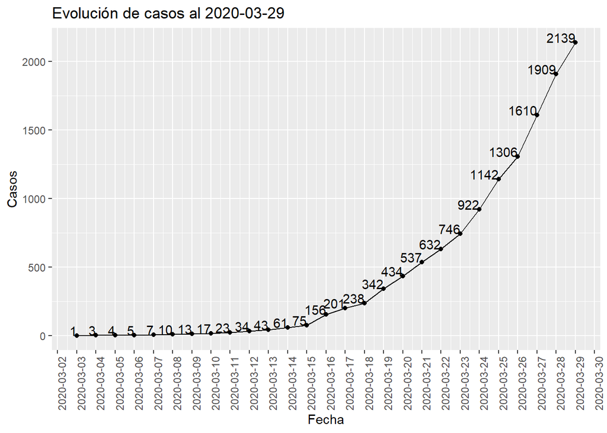

# Análisis del punto de Inflexión del modelo logístico

Cuando el factor de crecimiento sea consistentemente $<1$ podemos presumir que la curva logística habrá pasado su punto de inflexión y el modelo exponencial ha de actualizarse a uno que inculya factores de saturación.

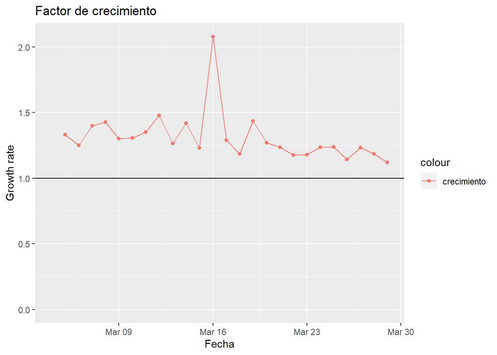

# Análisis del ajuste de los modelos

A continuación se presentan los modelos desarrollados. Desde el último enfoque hasta el primer enfoque abordado en el tiempo

### LOESS

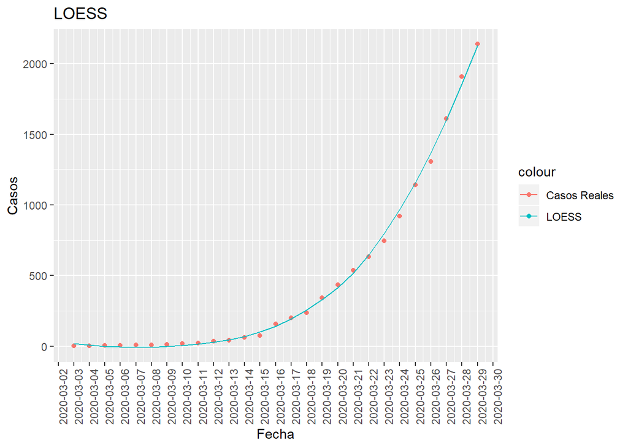

```
##  El error promedio de las predicciones es = 24.21288 personas
```

### Ensembled Model

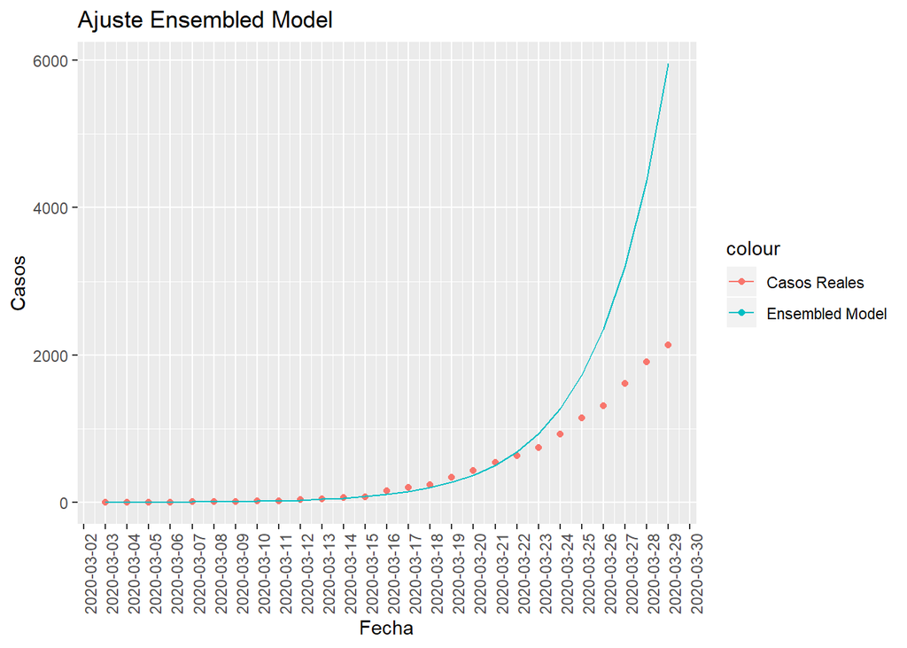

```
##  El error promedio de las predicciones es = 958.1517 personas
```